# Getting Started with gghdr

The `gghdr` imports the [`hdrcde` package](https://cran.r-project.org/package=hdrcde) and provides tools for plotting highest density regions with [`ggplot2`](https://ggplot2.tidyverse.org/).

> The following vignette assumes familiarity with the grammar of graphics as implemented in ggplot2.

## Introduction: the limitations of a boxplot

In a standard boxplot:

- The central box is bounded by Q1 and Q3, which represents the interquartile range.
- The whiskers extend from Q1 - 1.5 (Q3 - Q1) to Q3 + to 1.5 (Q3 - Q1), which represents 99% coverage for large samples.
- Finally, the horizontal line represents the median.

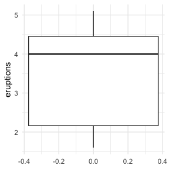

```r
library(ggplot2)
theme_set(theme_minimal())
ggplot(data = faithful, aes(y = eruptions)) +
  geom_boxplot()
```

If we look more closely at our data, however, we can see that it’s actually multimodal, but our choice of visualisation technique limited our ability to see this:

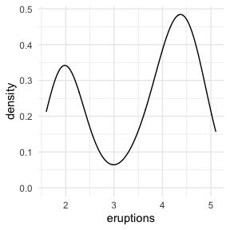

```r
ggplot(data = faithful, aes(x = eruptions)) + geom_density()
```

## High-density regions (HDRs) enable us to effectively summarise and visualise multimodal datasets

The [`hdrcde package`](https://cran.r-project.org/package=hdrcde) is an R package that allows us to address this. It provides a way of calculating and visualising so-called high-density regions (HDRs), which can intuitively be understood as boxplot-like plots, with darker boxes showing regions of higher data density. For example, a light rectangle might be used to show the region in which over 99% of the data is contained, whereas a smaller, darker rectangle would highlight a region within that which contains the most closely co-localised 50% of the dataset.

Formally, HDRs are [defined in the following manner (Hyndman 1996 American Statistician, **50**, 120-126)](https://robjhyndman.com/publications/computing-and-graphing-highest-density-regions/):

> If $f(x)$ is the density function of a random variable X, then the $100 (1 -\alpha)$ HDR is the subset R($f_\alpha$) of the sample space of X such that $R(f_\alpha) = \{x: f(x) \geq f_\alpha\}$, where $f_\alpha$ is the largest constant such that Pr(X $\in R(f_\alpha)) \geq 1-\alpha$)

The [`hdrcde package`](https://cran.r-project.org/package=hdrcde) provides tools for computing these highest density regions in one and two dimensions, kernel estimates of univariate density functions conditional on one covariate, and multimodal regression.

We can use this package to create a density plot of the `eruptions` variable.

```r
library(hdrcde)
hdr_info <- hdr.den(
  faithful$eruptions,
  col = c("skyblue", "slateblue2", "slateblue4")
)
```

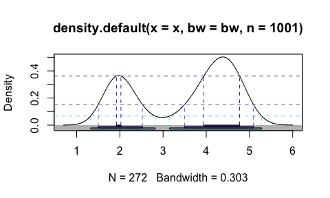

- 50% of the dataset is “located” in the regions shown by the darkest blue rectangles/dashed lines
- 95% of the dataset is “located” in the regions shown by the blue rectangles/dashed lines
- 99% of the dataset is “located” in the regions shown by the light blue rectangles/dashed lines

This can be visualised more compactly using the `hdr.boxplot` function, in which:

- The region bounded by the interquartile range is replaced by 50% HDR (dark blue)
- The region shown using the whiskers is replaced by the 99% HDR (light blue)
- The horizontal line represents the mode

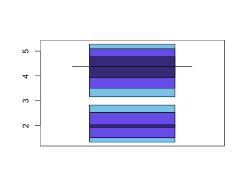

```r
hdr.boxplot(faithful$eruptions,
            prob = c(99, 95, 50),
            col = c("skyblue", "slateblue2", "slateblue4"))
```

`hdr.boxplot()` uses base plotting tools to create the visualisation, limiting users’ ability to customise and combine it with other `ggplot2` visualisations.

## HDR boxplots in ggplot2: `geom_hdr_boxplot()`

We can visualise the same dataset using `geom_hdr_boxplot()`. By default, it will plot respectively darker boxes for 99%, 95% or 50% of the data.

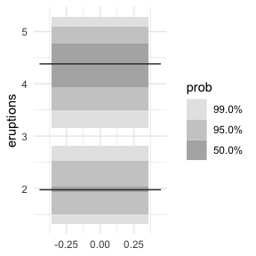

```r
library(gghdr)
ggplot(data = faithful,
       aes(y = eruptions)) +
  geom_hdr_boxplot()
```

## Adding colour

We can specify the base colour we’d like to use.

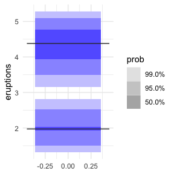

```r
ggplot(data = faithful,
       aes(y = eruptions)) +
  geom_hdr_boxplot(fill = c("blue"))
```

## Specifying your own probabilities

We can also specify which set of probability coverages we’d like to display HDRs for. For example, we can visualise the 25%, 50%, 75%, 95%, and 99% HDR of the faithful eruptions.

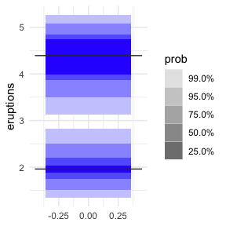

```r
ggplot(data = faithful,
       aes(y = eruptions)) +
  geom_hdr_boxplot(prob = c(0.25, 0.5, 0.75, 0.95, 0.99),
                   fill = c("blue"))
```

We can also specify the probabilities as percentages, i.e. out of 100.

```
#> Warning: Probability values should be on a scale between 0 to 1. If not, values
#> will be converted to decimal values.
```

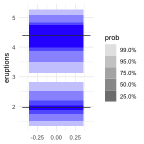

```r
ggplot(data = faithful,
       aes(y = eruptions)) +
  geom_hdr_boxplot(prob = c(25, 50, 75, 95, 99),
                   fill = c("blue"))
```

```
#> Warning: Probability values should be on a scale between 0 to 1. If not, values
#> will be converted to decimal values.
```

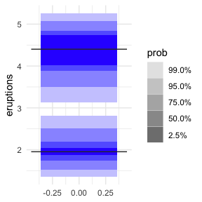

```r
ggplot(data = faithful,
       aes(y = eruptions)) +
  geom_hdr_boxplot(prob = c(2.55, 50, 75, 95, 99),
                   fill = c("blue"))
```

## Combining `geom_hdr_boxplot()` with `geom_jitter()` to visualise both the raw data and HDRs

We can combine all sorts of ggplot2 geometries with `geom_hdr_boxplot()`. For example, we can use `geom_jitter()` to showcase the underlying data.

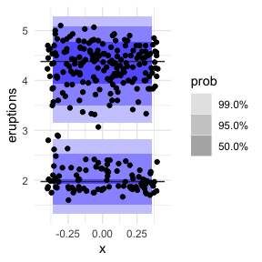

```r
ggplot(data = faithful,
       aes(y = eruptions)) +
  geom_hdr_boxplot(fill = c("blue")) +
  geom_jitter(aes(x = 0))
```

## Combining `geom_hdr_boxplot()` with `geom_rug()` to visualise the HDRs and distribution of the data

We can use `geom_rug()` to show this distribution in the margin along the y axis.

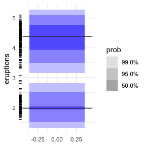

```r
ggplot(data = faithful, aes(y = eruptions)) +
  geom_hdr_boxplot(fill = c("blue")) +
  geom_rug()
```

## Marginal HDRs are supported with `geom_hdr_rug()`

Inspired by this feature of `geom_rug()`, we provide `geom_hdr_rug()`, which enables us to plot HDRs in the margins of other plots.

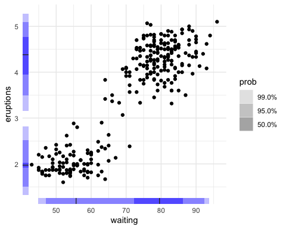

```r
ggplot(data = faithful, aes(x = waiting, y = eruptions)) +
  geom_point() +
  geom_hdr_rug(fill = "blue")
```

`geom_hdr_rug()` supports multiple probability specifications, just like `geom_hdr_boxplot()`. It expects probabilities between 0 and 1, but, similarly to `geom_hdr_boxplot()`, it will complain but accept probabilities between 0 and 100.

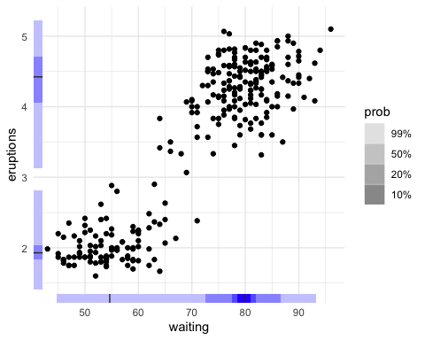

```r
ggplot(data = faithful, aes(x = waiting, y = eruptions)) +
  geom_point() +
  geom_hdr_rug(prob = c(10, 20, 50, 99), fill = "blue")
```

## Grouped HDR boxplots

One of the most exciting features `geom_hdr_boxplot()` supports (unlike `hdr.boxplot`) is the ability to create separate HDR boxplots for different groups in a dataset. We use ggplot2’s native syntax to do this. Let’s explore the `ggplot2::mpg` dataset. First, let’s look at a histogram of the data, faceted by number of cylinders

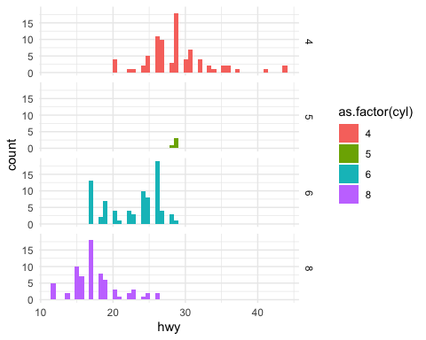

```r
ggplot(data = mpg,
       aes(x = hwy, fill = as.factor(cyl))) +
  facet_grid(as.factor(cyl)~.) +
  geom_histogram(bins = 50)
```

We can see that cars with 6 cylinders seem to be bimodally distributed. As expected, `geom_hdr_boxplot()` nicely shows us both modes in the data.

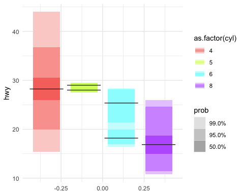

```r
ggplot(data = mpg,
       # make sure to change x to y from geom_density to geom_hdr_boxplot
       aes(y = hwy, fill = as.factor(cyl))) +
  geom_hdr_boxplot()
```

## Scatterplots with HDR information

`gghdr` provides the `hdr_bin()` function for annotating data with the HDR they fall under. Providing this to the `colour` aesthetic produces scatterplots with the HDR information.

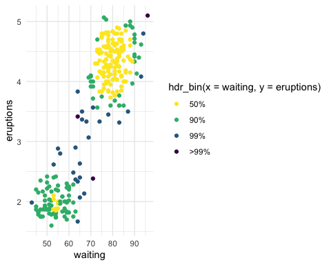

```r
ggplot(data = faithful, aes(x = waiting, y = eruptions)) +
  geom_point(aes(colour = hdr_bin(x = waiting, y = eruptions))) +
  scale_colour_viridis_d(direction = -1)
```

Feel free to combine this with a rug for more `gghdr` goodness.

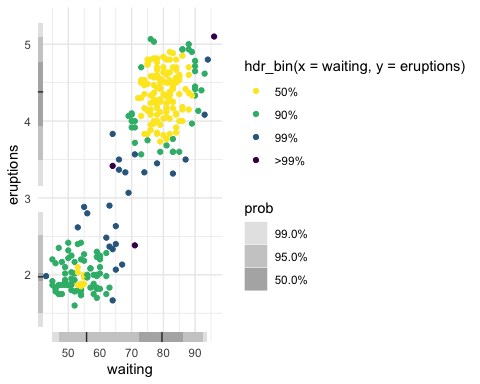

```r
ggplot(data = faithful, aes(x = waiting, y = eruptions)) +
  geom_point(aes(colour = hdr_bin(x = waiting, y = eruptions))) +
  geom_hdr_rug() +
  scale_colour_viridis_d(direction = -1)
```